# Monaco Experiment Models

Natalija Suhareva

2024-11-03

Start with uloading all necessary libraries.

```r
# Set global options
knitr::opts_chunk$set(echo = TRUE, warning = FALSE, message = FALSE)

# Load required libraries
library(readxl)   # For reading Excel files
library(ggplot2)  # For creating visualizations
library(mgcv)     # For Generalized Additive Models (GAM)
library(plyr)     # For data manipulation
library(dplyr)    # For modern data manipulation
library(purrr)    # For functional programming
library(car)      # For Levene's test
```

Upload data sets of single stressor experiments.

```r
# Import the dataset from the specified file path
# Replace the file path with a relative path if needed for better portability
full_data_single <- read_excel("~/Personal documents/OA/GR_experiment/correspondance with einar/full_data_single.xlsx")

# Rename the columns of the dataset for clarity and consistency
# - Treatment: Experimental treatment group
# - T_targeted: Target temperature for the experiment
# - pH_targeted: Target pH level for the experiment
# - Li_targeted: Target lithium concentration for the experiment
# - T_measured: Measured temperature during the experiment
# - pH_measured: Measured pH level during the experiment
# - Li_measured: Measured lithium concentration during the experiment
# - BL: Body length of the larvae
# - GR: Growth rate of the larvae
names(full_data_single) <- c("Treatment", "T_targeted", "pH_targeted", "Li_targeted",
                             "T_measured", "pH_measured", "Li_measured", "BL", "GR")
```

Split data sets on sub-sets per single stressor.

```r
# Subset data for temperature experiments
# Select rows 1 to 57 and relevant columns:
# - Column 1: Treatment
# - Column 2: Targeted temperature (T_targeted)
# - Column 5: Measured temperature (temp)
# - Column 9: Growth rate (rate)
temp_only <- full_data_single[1:57, c(1,2,5,9)]
names(temp_only) <- c("Treatment", "T_targeted", "temp", "rate")  # Rename columns for clarity

# Subset data for pH experiments
# Select rows 58 to 109 and relevant columns:
# - Column 1: Treatment
# - Column 3: Targeted pH (pH_targeted)
# - Column 6: Measured pH (pH)
# - Column 9: Growth rate (rate)
pH_only <- full_data_single[58:109, c(1,3,6,9)]
names(pH_only) <- c("Treatment", "pH_targeted", "pH", "rate")  # Rename columns for clarity

# Subset data for lithium experiments
# Select rows 110 to 190 and relevant columns:
# - Column 1: Treatment
# - Column 4: Targeted lithium concentration (Li_targeted)
# - Column 7: Measured lithium concentration (lithium)
# - Column 9: Growth rate (rate)
lithium_only <- full_data_single[110:190, c(1,4,7,9)]
names(lithium_only) <- c("Treatment", "Li_targeted", "lithium", "rate")  # Rename columns for clarity
```

Data exploration

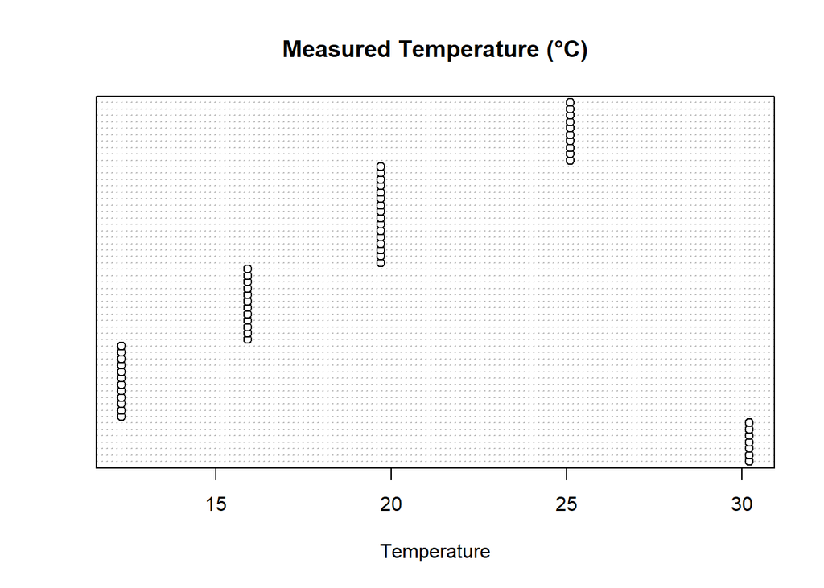

```r
# Visualize the data distribution with dot charts
# Dot charts help visualize the spread of measured values and growth rates for each stressor

# Temperature experiments: Measured temperature and growth rate
dotchart(temp_only$temp, main = "Measured Temperature (°C)", xlab = "Temperature")
```

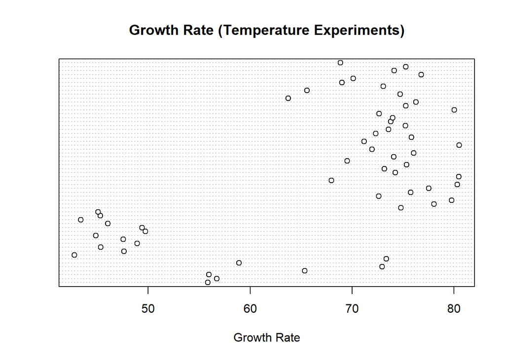

```r
dotchart(temp_only$rate, main = "Growth Rate (Temperature Experiments)", xlab = "Growth Rate")
```

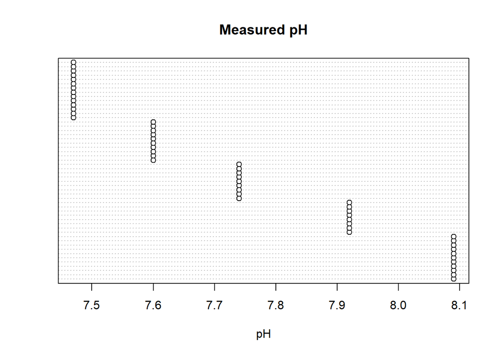

```r
# pH experiments: Measured pH and growth rate
dotchart(pH_only$pH, main = "Measured pH", xlab = "pH")
```

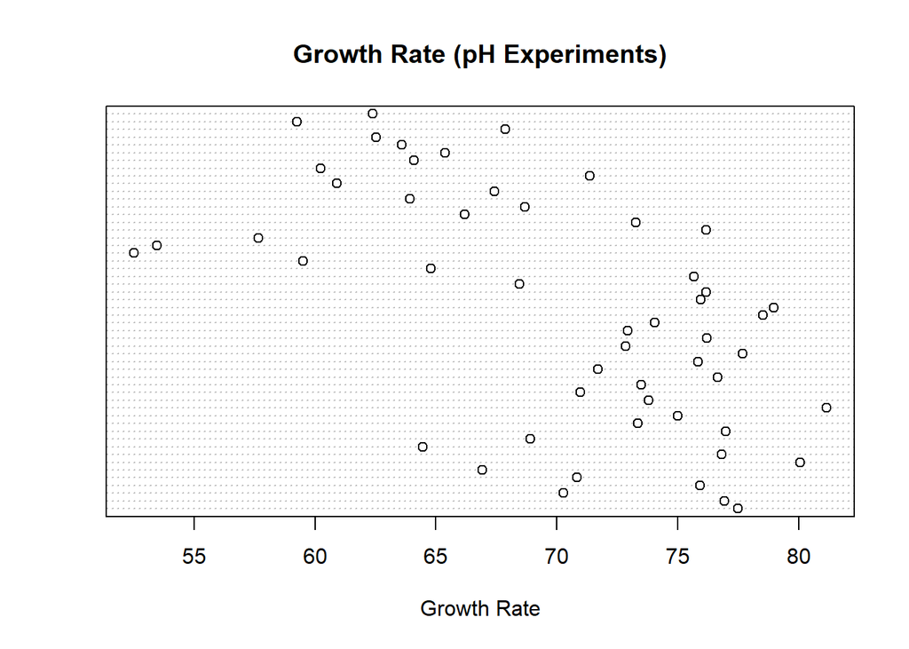

```r
dotchart(pH_only$rate, main = "Growth Rate (pH Experiments)", xlab = "Growth Rate")
```

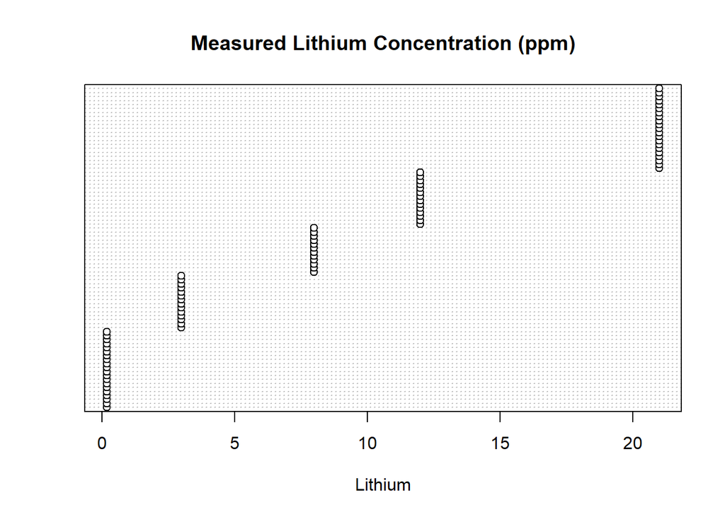

```r
# Lithium experiments: Measured lithium concentration and growth rate
dotchart(lithium_only$lithium, main = "Measured Lithium Concentration (ppm)", xlab = "Lithium")
```

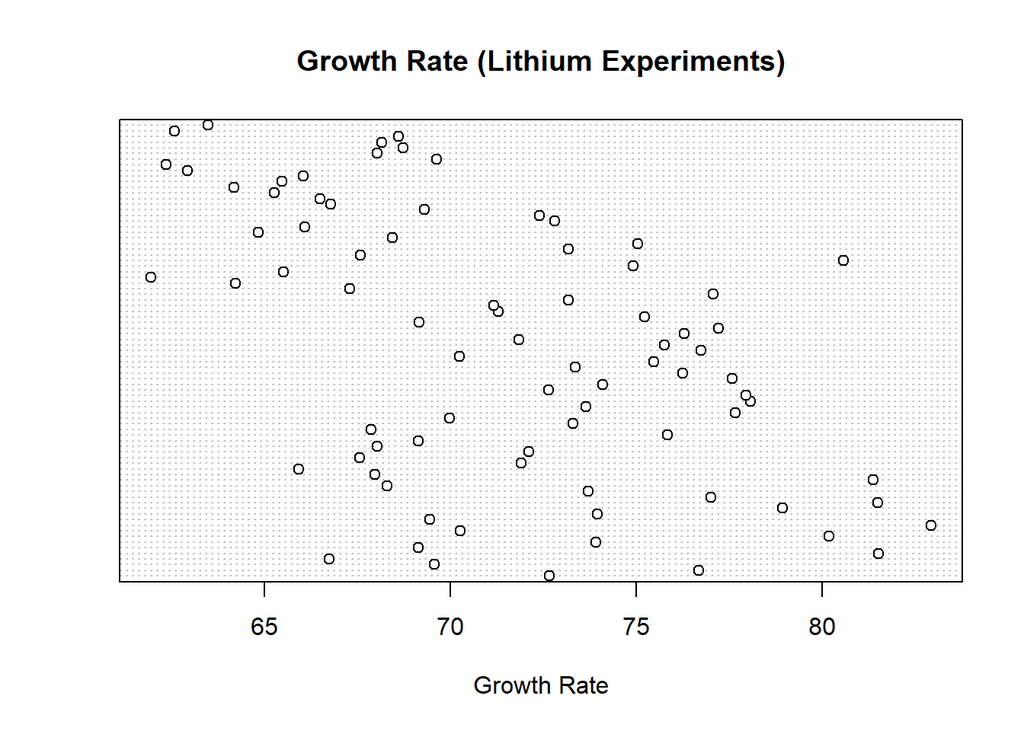

```r
dotchart(lithium_only$rate, main = "Growth Rate (Lithium Experiments)", xlab = "Growth Rate")
```

### **Exploration of how the single stressors temperature, pH and Li affect growth rate**

According to the literature, the performance curves of growth rates impacted by stressors such as temperature and pH typically exhibit a bell-shaped curve. These curves are often well-described by a quadratic function or a second-degree polynomial. In contrast, lithium acts as a toxicant, leading to an S-shaped performance curve. This curve reflects a plateau of tolerance, followed by a sharp decrease in growth rate and then another plateau of indifference at higher concentrations.

**Model selection for temperature**

```r
# Fit a simple linear model to temperature data (reference model)
LM_temp <- lm(rate ~ temp, data = temp_only)
summary(LM_temp)  # Check the summary for model performance
```

```
##
## Call:
## lm(formula = rate ~ temp, data = temp_only)
##
## Residuals:
##     Min      1Q  Median      3Q     Max
## -18.918 -12.265   3.990   8.941  16.275
##
## Coefficients:
##             Estimate Std. Error t value Pr(>|t|)
## (Intercept)  52.9540     5.3630   9.874 8.77e-14 ***
## temp          0.7085     0.2628   2.696  0.00928 **
## ---
## Signif. codes:  0 '***' 0.001 '**' 0.01 '*' 0.05 '.' 0.1 ' ' 1
##
## Residual standard error: 11.43 on 55 degrees of freedom
## Multiple R-squared:  0.1168, Adjusted R-squared:  0.1007
## F-statistic: 7.271 on 1 and 55 DF,  p-value: 0.009283
```

```r
# Fit a polynomial model (degree 2) to capture the bell-shaped curve
P2_temp <- lm(rate ~ poly(temp, 2), data = temp_only)
summary(P2_temp)  # Check the performance of the polynomial model
```

```
##
## Call:
## lm(formula = rate ~ poly(temp, 2), data = temp_only)
##
## Residuals:
##     Min      1Q  Median      3Q     Max
## -11.819  -4.552  -1.435   4.000  14.047
##
## Coefficients:
##                Estimate Std. Error t value Pr(>|t|)
## (Intercept)     66.8264     0.8723  76.607  < 2e-16 ***
## poly(temp, 2)1  30.8266     6.5860   4.681 1.96e-05 ***
## poly(temp, 2)2 -69.6155     6.5860 -10.570 9.26e-15 ***
## ---
## Signif. codes:  0 '***' 0.001 '**' 0.01 '*' 0.05 '.' 0.1 ' ' 1
##
## Residual standard error: 6.586 on 54 degrees of freedom
## Multiple R-squared:  0.7122, Adjusted R-squared:  0.7016
## F-statistic: 66.82 on 2 and 54 DF,  p-value: 2.482e-15
```

```r
# Fit a Generalized Additive Model (GAM) for comparison
GAM_temp <- gam(rate ~ s(temp, k = 1), family = Gamma(link = "log"), data = temp_only)
summary(GAM_temp)
```

```
##
## Family: Gamma
## Link function: log
##
## Formula:
## rate ~ s(temp, k = 1)
##
## Parametric coefficients:
##             Estimate Std. Error t value Pr(>|t|)
## (Intercept)  4.18953    0.01504   278.5   <2e-16 ***
## ---
## Signif. codes:  0 '***' 0.001 '**' 0.01 '*' 0.05 '.' 0.1 ' ' 1
##
## Approximate significance of smooth terms:
##          edf Ref.df     F p-value
## s(temp) 1.99      2 60.91  <2e-16 ***
## ---
## Signif. codes:  0 '***' 0.001 '**' 0.01 '*' 0.05 '.' 0.1 ' ' 1
##
## R-sq.(adj) =  0.631   Deviance explained = 68.4%
## GCV = 0.012959  Scale est. = 0.012901  n = 57
```

```r
# Compare model performance using AIC (Akaike Information Criterion)
AIC(LM_temp, P2_temp, GAM_temp)
```

```
##                df      AIC
## LM_temp  3.000000 443.4791
## P2_temp  4.000000 381.5603
## GAM_temp 3.990389 393.2347
```

*Linear Model for Temperature:*

A GAM was tested to explore whether it could further improve the fit. With k = 1, the Adjusted R-squared was 0.631, which was lower than the polynomial model. Increasing k to 4 improved the Adjusted R-squared to 0.75, but the resulting model became harder to interpret biologically. Therefore, the polynomial model was preferred due to its simplicity and alignment with theoretical expectations. *Model Selection using AIC:*

The Akaike Information Criterion (AIC) was calculated to compare the linear, polynomial, and GAM models. The second-degree polynomial model was found to be the most appropriate based on AIC values.

*Validate the polynomial model (P2_temp)*

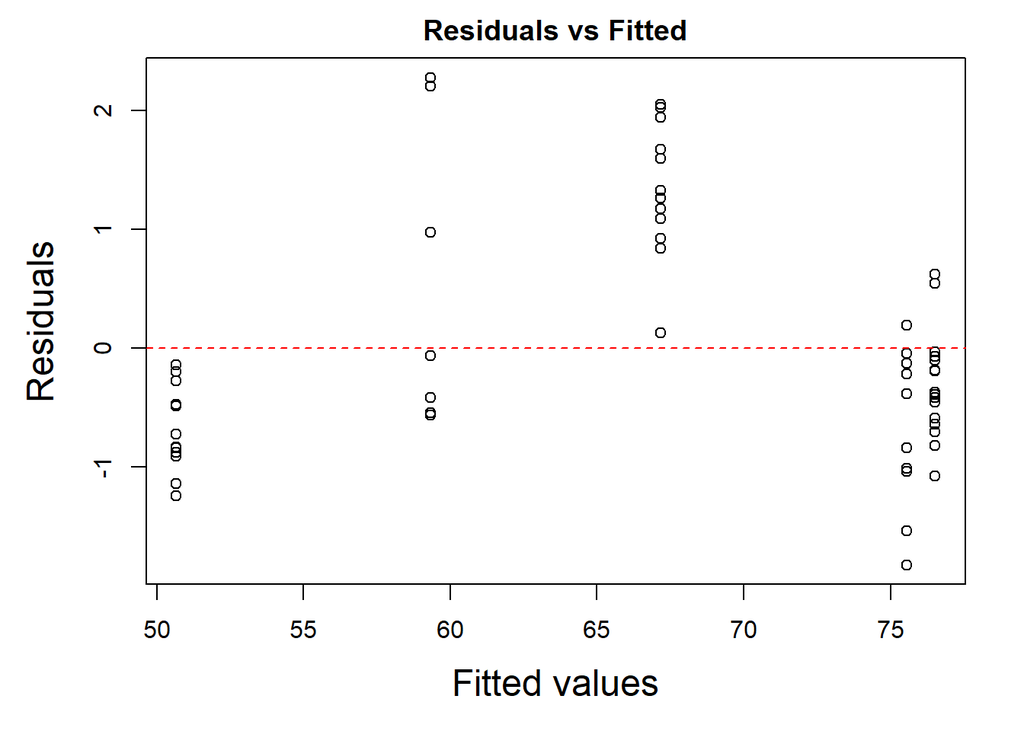

```r
# Check homogeneity by extracting residuals and fitted values
E2 <- rstandard(P2_temp)  # Standardized residuals
F2 <- fitted(P2_temp)     # Fitted values

# Plot residuals vs fitted values to check for patterns
par(mfrow = c(1, 1), mar = c(5, 5, 2, 2), cex.lab = 1.5)
plot(F2, E2, xlab = "Fitted values", ylab = "Residuals", main = "Residuals vs Fitted")
abline(h = 0, col = "red", lty = 2)
```

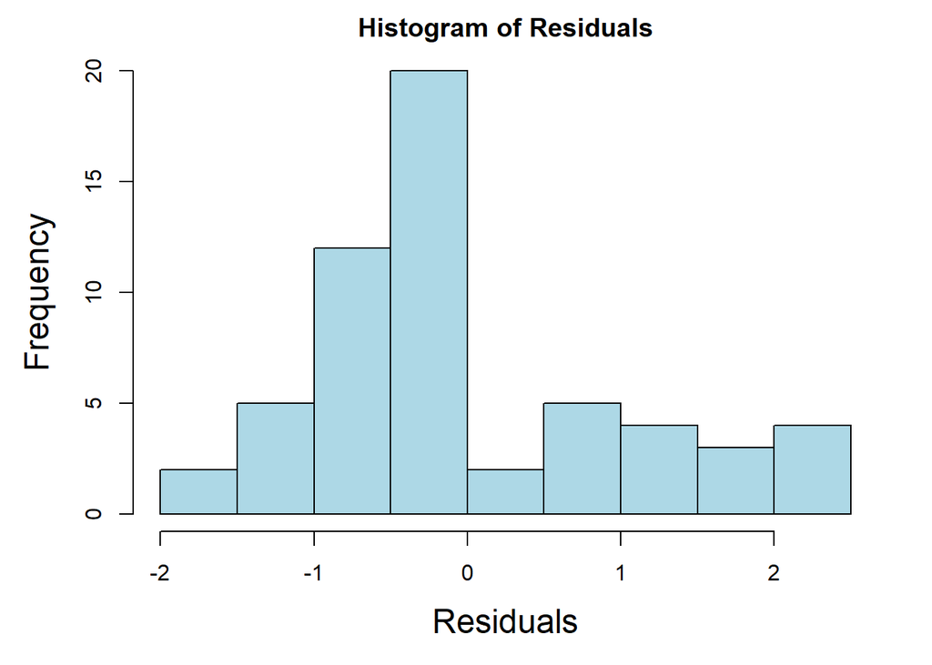

```r
# Check normality of residuals using a histogram
hist(E2, main = "Histogram of Residuals", xlab = "Residuals", col = "lightblue", border = "black")
```

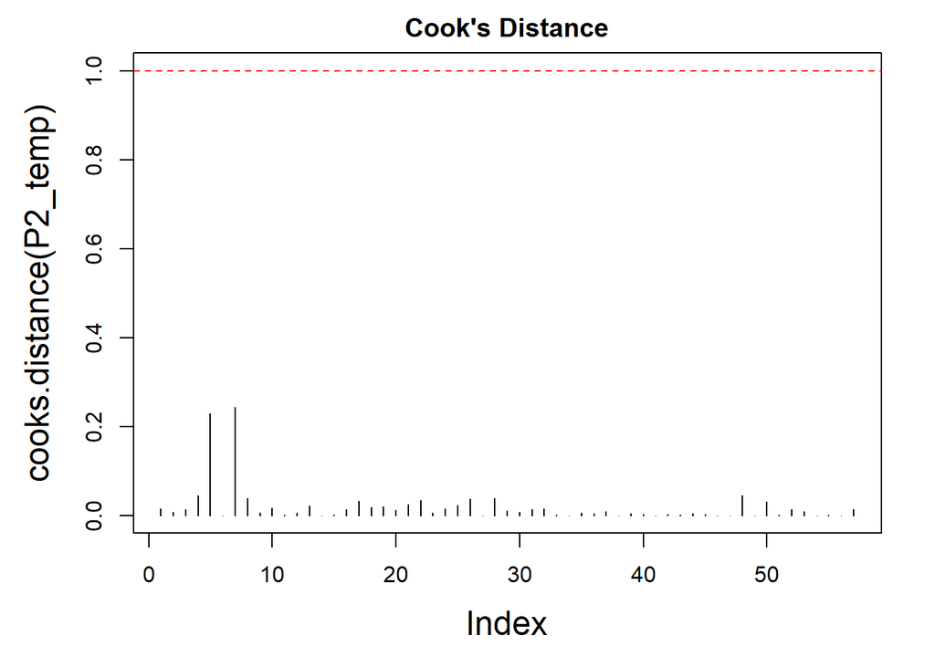

```r
# Check for influential observations using Cook's Distance
par(mfrow = c(1, 1), mar = c(5, 5, 2, 2), cex.lab = 1.5)
plot(cooks.distance(P2_temp), type = "h", ylim = c(0, 1), main = "Cook's Distance")
abline(h = 1, col = "red", lty = 2)
```

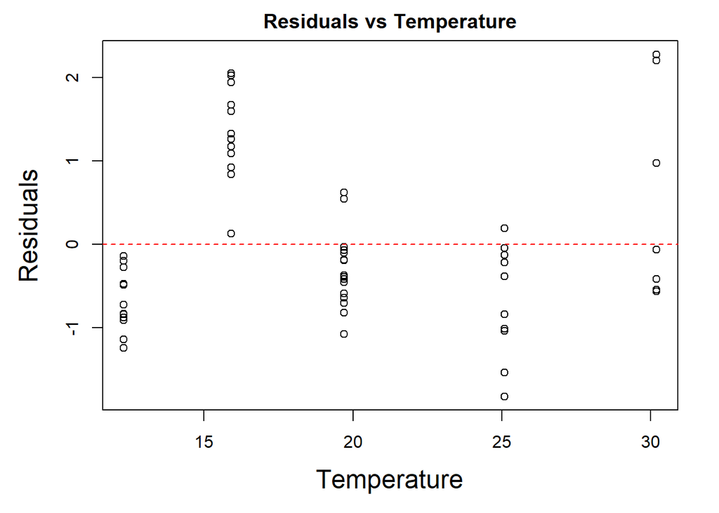

```r
# Check for independence by plotting residuals against temperature
temp_only$E2 <- E2
plot(temp_only$temp, temp_only$E2, main = "Residuals vs Temperature", xlab = "Temperature", ylab = "Residuals")
abline(h = 0, col = "red", lty = 2)
```

*Cross-validation* *Extended Predictions:* To better understand the performance curve, predictions were extended by adding hypothetical “tails” with lower and higher temperature values beyond the experimental range. A confidence interval was calculated for these predictions to provide a sense of uncertainty.

```r
MyData <- expand.grid(temp = seq(min(temp_only$temp) - 5, max(temp_only$temp) + 5, length = 25))

# Predict growth rate and calculate confidence intervals for new data
P2 <- predict(P2_temp, newdata = MyData, se = TRUE)
MyData$Pred <- P2$fit                     # Predicted values
MyData$selo <- P2$fit - 1.96 * P2$se.fit  # Lower bound of 95% CI
MyData$seup <- P2$fit + 1.96 * P2$se.fit  # Upper bound of 95% CI
```

*Visualization:*

Observed data points were plotted to show the actual growth rates. The model prediction curve was overlaid to show the fitted polynomial model. A ribbon was added to indicate the confidence interval around the predictions. The plot clearly illustrated the bell-shaped performance curve expected from the literature.

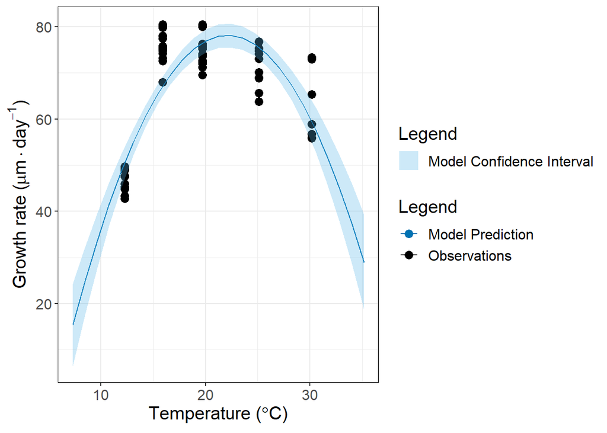

```r
p <- ggplot() +
  geom_point(data = temp_only,
             aes(x = temp, y = rate, color = "Observations"),
             shape = 16, size = 3) +
  geom_line(data = MyData,
            aes(x = temp, y = Pred, color = "Model Prediction"),
            linetype = "solid") +
  geom_ribbon(data = MyData,
              aes(x = temp, ymin = selo, ymax = seup, fill = "Model Confidence Interval"),
              alpha = 0.3) +
  xlab(expression(paste("Temperature ("*degree*"C)"))) +
  ylab(expression(paste("Growth rate ("*mu*"m"%.%"day"^-1*")"))) +
  theme_bw() +
  theme(text = element_text(size = 15)) +
  scale_color_manual(name = "Legend",
                     values = c("Observations" = "#000000", "Model Prediction" = "#0072B2")) +
  scale_fill_manual(name = "Legend",
                    values = c("Model Confidence Interval" = "#56B4E9"))

p
```

**Model selection for pH stressor**

Similarely as for temperature stressor, the growth rate’s relationship with pH is expected to follow a bell-shaped curve based on the literature. We test this assumption by fitting and comparing several models: a simple linear model, a second-degree polynomial model, and a Generalized Additive Model (GAM). Each model’s performance is evaluated to determine the best representation.

```r
#Step 1: Fit a Linear Model
LM_pH<- lm(rate~pH, data=pH_only)# start with the simple linear for the reference
summary(LM_pH)
```

```
##
## Call:
## lm(formula = rate ~ pH, data = pH_only)
##
## Residuals:
##      Min       1Q   Median       3Q      Max
## -15.3119  -3.2508   0.7165   4.0492   8.8823
##
## Coefficients:
##             Estimate Std. Error t value Pr(>|t|)
## (Intercept)  -54.382     27.605  -1.970   0.0544 .
## pH            16.081      3.564   4.512 3.91e-05 ***
## ---
## Signif. codes:  0 '***' 0.001 '**' 0.01 '*' 0.05 '.' 0.1 ' ' 1
##
## Residual standard error: 5.988 on 50 degrees of freedom
## Multiple R-squared:  0.2893, Adjusted R-squared:  0.2751
## F-statistic: 20.36 on 1 and 50 DF,  p-value: 3.912e-05
```

```r
#Step 2: Fit a Second-Degree Polynomial Model
P2_pH<- lm(rate~poly(pH,2), data=pH_only)# quadratic function accoeding to the literature
summary(P2_pH)
```

```
##
## Call:
## lm(formula = rate ~ poly(pH, 2), data = pH_only)
##
## Residuals:
##      Min       1Q   Median       3Q      Max
## -16.6391  -2.7950   0.3982   3.8798   7.7634
##
## Coefficients:
##              Estimate Std. Error t value Pr(>|t|)
## (Intercept)   70.1162     0.7781  90.111  < 2e-16 ***
## poly(pH, 2)1  27.0187     5.6111   4.815 1.45e-05 ***
## poly(pH, 2)2 -15.8187     5.6111  -2.819  0.00693 **
## ---
## Signif. codes:  0 '***' 0.001 '**' 0.01 '*' 0.05 '.' 0.1 ' ' 1
##
## Residual standard error: 5.611 on 49 degrees of freedom
## Multiple R-squared:  0.3885, Adjusted R-squared:  0.3636
## F-statistic: 15.57 on 2 and 49 DF,  p-value: 5.837e-06
```

```r
#Step 3: Fit a Generalized Additive Model (GAM)
gam_pH<- gam(rate~s(pH,k=1), family='gaussian', data=pH_only)# quadratic function accoeding to the literature
summary(gam_pH)
```

```
##
## Family: gaussian
## Link function: identity
##
## Formula:
## rate ~ s(pH, k = 1)
##
## Parametric coefficients:
##             Estimate Std. Error t value Pr(>|t|)
## (Intercept)  70.1162     0.7736   90.64   <2e-16 ***
## ---
## Signif. codes:  0 '***' 0.001 '**' 0.01 '*' 0.05 '.' 0.1 ' ' 1
##
## Approximate significance of smooth terms:
##         edf Ref.df     F  p-value
## s(pH) 1.884  1.987 16.69 8.35e-06 ***
## ---
## Signif. codes:  0 '***' 0.001 '**' 0.01 '*' 0.05 '.' 0.1 ' ' 1
##
## R-sq.(adj) =  0.371   Deviance explained = 39.4%
## GCV = 32.945  Scale est. = 31.118    n = 52
```

```r
#Step 4: Compare Models Using AIC
AIC(LM_pH, P2_pH, gam_pH)
```

```
##              df      AIC
## LM_pH  3.000000 337.6689
## P2_pH  4.000000 331.8524
## gam_pH 3.883956 331.1356
```

*Linear Model for pH* The linear model’s Adjusted R-squared is 0.27, and the Residual Standard Error (SE) is 5.988. While the model provides a basic reference, its performance is limited. *Polynomial Model for pH:* The polynomial model improves the Adjusted R-squared slightly to 0.36, with a similar Residual SE of 5.6. This indicates a marginally better fit compared to the linear model, aligning better with the expected bell-shaped curve. *Generalized Additive Model (GAM):* The GAM achieves an Adjusted R-squared of 0.37 for all tested values of k (k = 1, 2, 3). This suggests no significant improvement over the polynomial model.

The observed data suggests a near-linear relationship within the experimental range. However, the quadratic model is retained based on theoretical expectations, as it reflects the bell-shaped curve predicted by the literature. Within the scope of this dataset, the quadratic model behaves similarly to a linear model due to the limited range of pH values.

*Validate the polynomial model (P2_pH)*

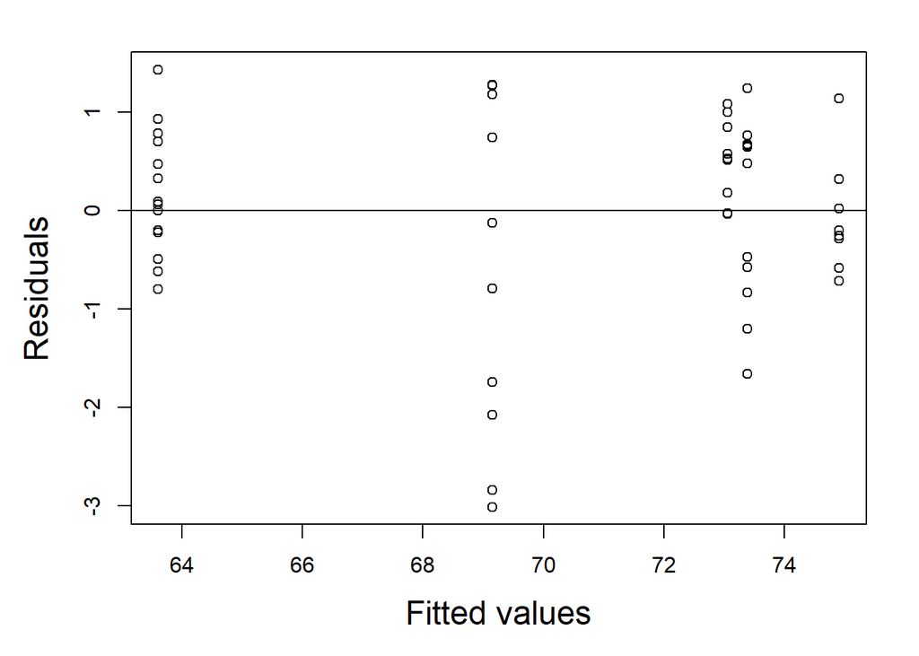

```r
# Homogeneity
E2 <- rstandard(P2_pH)
F2 <- fitted(P2_pH)

#Plot residuals vs fitted values
par(mfrow = c(1,1), mar = c(5,5,2,2), cex.lab = 1.5)
plot(x = F2,
     y = E2,
     xlab = "Fitted values",
     ylab = "Residuals")
abline(h = 0, v = 0)
```

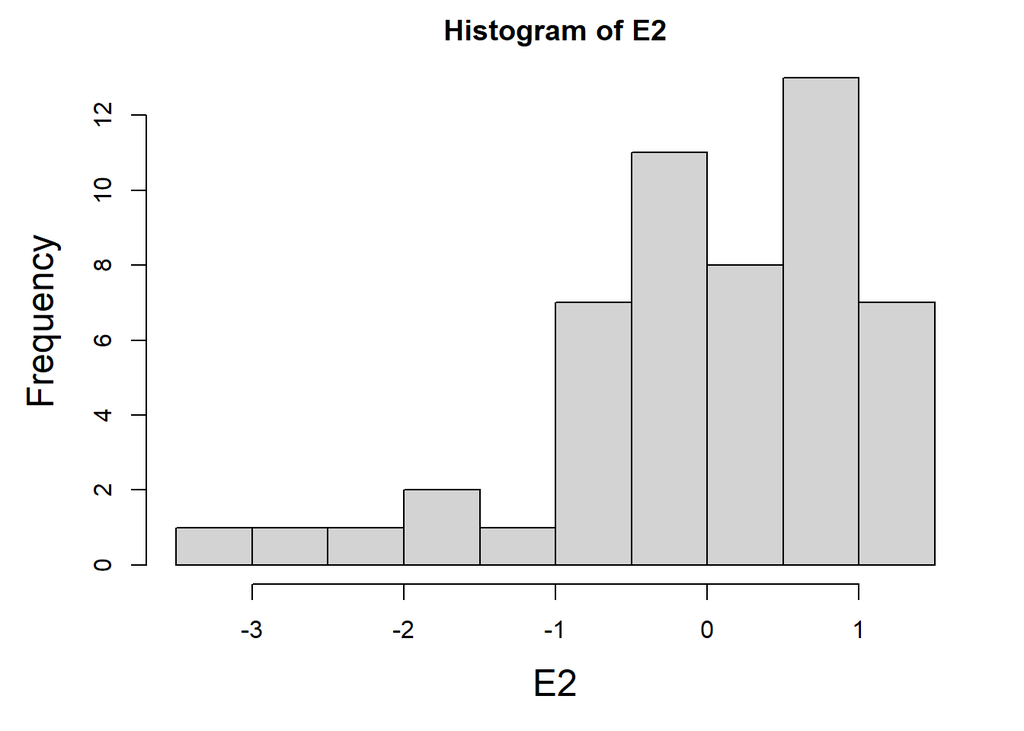

```r
# Normality
hist(E2)
```

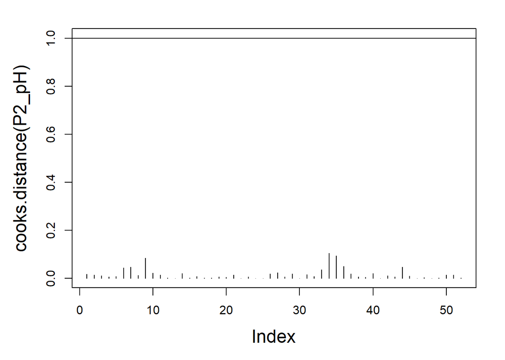

```r
# Influential observations
par(mfrow = c(1,1), mar = c(5,5,2,2), cex.lab = 1.5)
plot(cooks.distance(P2_pH), type = "h", ylim = c(0, 1))
abline(h = 1)
```

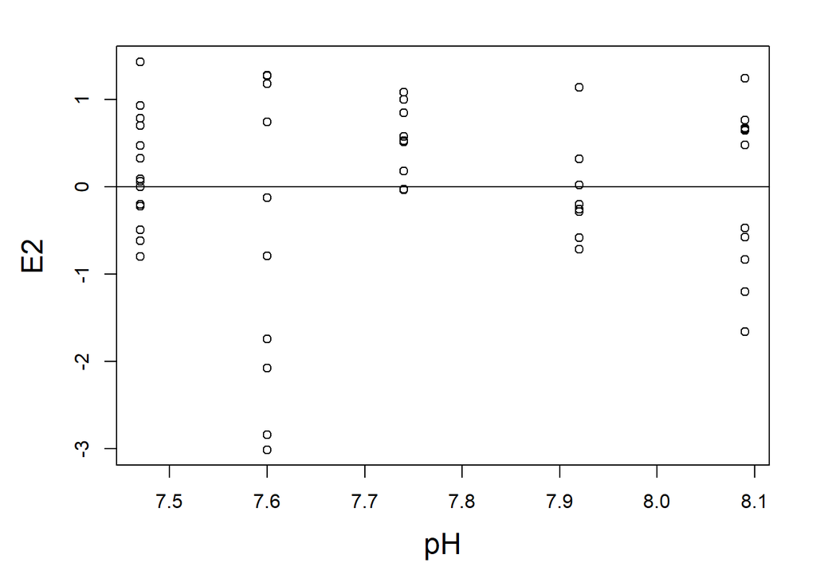

```r
# Independence due to model misfit
pH_only$E2 <- E2   #Put E2 inside the dataset
plot(E2~pH, data=pH_only)
abline(h = 0)
```

The validation confirms that the quadratic model for pH performs reasonably well. While minor deviations in residual normality and homogeneity are observed.

*Cross-validation*

```r
MyData <- expand.grid(pH = seq(min(pH_only$pH-0.3),
                                  max(pH_only$pH+0.3),
                                  length = 25),
                rate = seq(min(pH_only$rate),
                                  max(pH_only$rate),
                                  length = 25))
P2 <- predict(P2_pH, newdata = MyData, se = TRUE)

# 3. Calculate a measure of uncertainty for these predicted values.
#    Say a 95% confidence interval.
MyData$Pred <- P2$fit                    #Predicted values
MyData$selo <- P2$fit - 1.96 * P2$se.fit #lower bound
MyData$seup <- P2$fit + 1.96 * P2$se.fit #lower bound
head(MyData)
```

```
##         pH   rate     Pred     selo     seup
## 1 7.170000 52.519 43.71883 31.09745 56.34021
## 2 7.220833 52.519 47.78512 37.39239 58.17784
## 3 7.271667 52.519 51.56747 43.19376 59.94118
## 4 7.322500 52.519 55.06589 48.49409 61.63770
## 5 7.373333 52.519 58.28038 53.27941 63.28136
## 6 7.424167 52.519 61.21094 57.52192 64.89996
```

*Visualization:*

Observed data points were plotted to show the actual growth rates. The model prediction curve was overlaid to show the fitted polynomial model. A ribbon was added to indicate the confidence interval around the predictions. The plot clearly illustrated the bell-shaped performance curve expected from the literature.

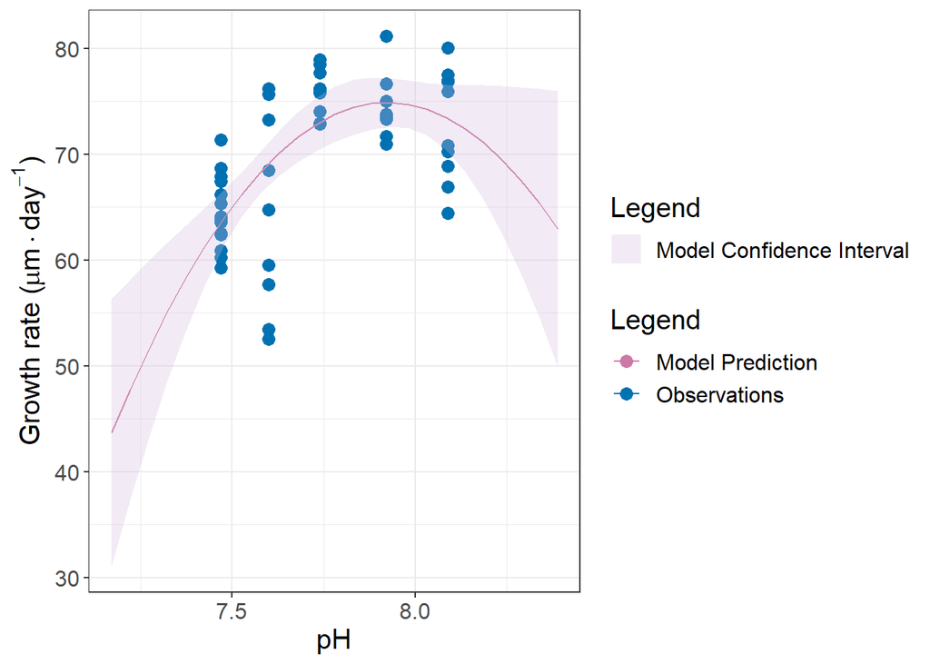

```r
p <- ggplot() +
  geom_point(data = pH_only,
             aes(y = rate, x = pH, color = "Observations"),
             shape = 16,
             size = 3) +
  geom_line(data = MyData,
            aes(x = pH, y = Pred, color = "Model Prediction"),
            linetype = "solid") +
  geom_ribbon(data = MyData,
              aes(x = pH, ymax = seup, ymin = selo, fill = "Model Confidence Interval"),
              alpha = 0.3) +
  xlab("pH") +
  ylab(expression(paste("Growth rate ("*mu*"m"%.%"day"^-1*")"))) +
  theme_bw() +
  theme(text = element_text(size = 15)) +
  scale_color_manual(name = "Legend",
                     values = c("Observations" = "#0072B2", "Model Prediction" = "#CC79A7")) +  # Colorblind-friendly palette
  scale_fill_manual(name = "Legend",
                    values = c("Model Confidence Interval" = "#D4B9DA"))  # Colorblind-friendly palette

p
```

**Model selection for Li stressor**

Lithium acts as a toxicant, and its effect on growth rate is expected to follow an S-shaped performance curve. This curve typically features:

A plateau of tolerance where the growth rate remains stable. A sharp decline in growth rate beyond a critical concentration. A plateau of indifference at high lithium levels where growth is negligible. The S-curve can theoretically be described by the logistic function: y~I(1 / (1 + exp(-x))).

To explore this, we fit several models to the data and evaluate their performance.

```r
#Step 1: Fit a Linear Model
LM_Li<-lm(rate~lithium, data=lithium_only)
summary(LM_Li)
```

```
##
## Call:
## lm(formula = rate ~ lithium, data = lithium_only)
##
## Residuals:
##     Min      1Q  Median      3Q     Max
## -8.6717 -3.3296 -0.1012  4.0235  9.9837
##
## Coefficients:
##             Estimate Std. Error t value Pr(>|t|)
## (Intercept) 74.66483    0.74541 100.166  < 2e-16 ***
## lithium     -0.34036    0.06081  -5.597 3.04e-07 ***
## ---
## Signif. codes:  0 '***' 0.001 '**' 0.01 '*' 0.05 '.' 0.1 ' ' 1
##
## Residual standard error: 4.39 on 79 degrees of freedom
## Multiple R-squared:  0.284,  Adjusted R-squared:  0.2749
## F-statistic: 31.33 on 1 and 79 DF,  p-value: 3.038e-07
```

```r
#Step 2: Fit a Second-Degree Polynomial Model
P2_Li<-lm(rate~poly(lithium, 2), data=lithium_only)
summary(P2_Li)
```

```
##
## Call:
## lm(formula = rate ~ poly(lithium, 2), data = lithium_only)
##
## Residuals:
##     Min      1Q  Median      3Q     Max
## -9.9114 -3.7721  0.0104  3.1442  9.2175
##
## Coefficients:
##                   Estimate Std. Error t value Pr(>|t|)
## (Intercept)        71.5100     0.4799 148.999  < 2e-16 ***
## poly(lithium, 2)1 -24.5728     4.3194  -5.689 2.14e-07 ***
## poly(lithium, 2)2  -8.2060     4.3194  -1.900   0.0612 .
## ---
## Signif. codes:  0 '***' 0.001 '**' 0.01 '*' 0.05 '.' 0.1 ' ' 1
##
## Residual standard error: 4.319 on 78 degrees of freedom
## Multiple R-squared:  0.3156, Adjusted R-squared:  0.2981
## F-statistic: 17.99 on 2 and 78 DF,  p-value: 3.771e-07
```

```r
#Step 3: Fit a Generalized Additive Model (GAM)
gam_Li<-gam(rate~s(lithium, k=5), data=lithium_only)
summary(gam_Li)
```

```
##
## Family: gaussian
## Link function: identity
##
## Formula:
## rate ~ s(lithium, k = 5)
##
## Parametric coefficients:
##             Estimate Std. Error t value Pr(>|t|)
## (Intercept)  71.5100     0.4796   149.1   <2e-16 ***
## ---
## Signif. codes:  0 '***' 0.001 '**' 0.01 '*' 0.05 '.' 0.1 ' ' 1
##
## Approximate significance of smooth terms:
##              edf Ref.df     F  p-value
## s(lithium) 1.809  2.158 16.18 1.11e-06 ***
## ---
## Signif. codes:  0 '***' 0.001 '**' 0.01 '*' 0.05 '.' 0.1 ' ' 1
##
## R-sq.(adj) =  0.299   Deviance explained = 31.5%
## GCV =   19.3  Scale est. = 18.63     n = 81
```

```r
#Step 4: Fit a Logit Model
logit_Li<-lm(rate~I(1/(1 + exp(-lithium))), data=lithium_only)
summary(logit_Li)
```

```
##
## Call:
## lm(formula = rate ~ I(1/(1 + exp(-lithium))), data = lithium_only)
##
## Residuals:
##     Min      1Q  Median      3Q     Max
## -8.5829 -4.0404 -0.2944  4.4968 10.0271
##
## Coefficients:
##                          Estimate Std. Error t value Pr(>|t|)
## (Intercept)                78.644      2.587  30.398  < 2e-16 ***
## I(1/(1 + exp(-lithium)))   -8.107      2.873  -2.822  0.00604 **
## ---
## Signif. codes:  0 '***' 0.001 '**' 0.01 '*' 0.05 '.' 0.1 ' ' 1
##
## Residual standard error: 4.945 on 79 degrees of freedom
## Multiple R-squared:  0.09156,    Adjusted R-squared:  0.08006
## F-statistic: 7.962 on 1 and 79 DF,  p-value: 0.00604
```

```r
#Step 5: Fit Exponential Model
exp_Li<-lm(rate~exp(lithium), data=lithium_only)
summary(exp_Li)
```

```
##
## Call:
## lm(formula = rate ~ exp(lithium), data = lithium_only)
##
## Residuals:
##      Min       1Q   Median       3Q      Max
## -11.2055  -3.2990   0.0205   2.8340   9.7594
##
## Coefficients:
##                Estimate Std. Error t value Pr(>|t|)
## (Intercept)   7.316e+01  5.618e-01 130.218  < 2e-16 ***
## exp(lithium) -4.827e-09  8.367e-10  -5.769 1.49e-07 ***
## ---
## Signif. codes:  0 '***' 0.001 '**' 0.01 '*' 0.05 '.' 0.1 ' ' 1
##
## Residual standard error: 4.352 on 79 degrees of freedom
## Multiple R-squared:  0.2964, Adjusted R-squared:  0.2875
## F-statistic: 33.28 on 1 and 79 DF,  p-value: 1.488e-07
```

```r
#Step 6: Compare Models Using AIC
AIC(LM_Li,logit_Li,P2_Li,gam_Li, exp_Li)
```

```
##                df      AIC
## LM_Li    3.000000 473.5007
## logit_Li 3.000000 492.7783
## P2_Li    4.000000 471.8368
## gam_Li   3.809186 471.5359
## exp_Li   3.000000 472.0780
```

The AIC results suggest that the polynomial model (degree 2), GAM, linear model, and exponential model are among the better-performing options. However, all models provide a relatively poor fit.

While the fit for all models is suboptimal, this aligns with the theoretical expectation that lithium’s toxic effect creates an S-shaped curve. Due to limitations in the data, particularly the wide gap between 15 and 20 ppm, it is difficult to pinpoint the elbow point where the growth rate sharply declines.

For further analysis, the second-degree polynomial model is selected. It provides a reasonable approximation of the curve while maintaining simplicity. This decision aligns with the theoretical understanding of lithium’s effect, though additional data at critical concentrations would improve the model’s accuracy.

*Validate the polynomial model (P2_Li)*

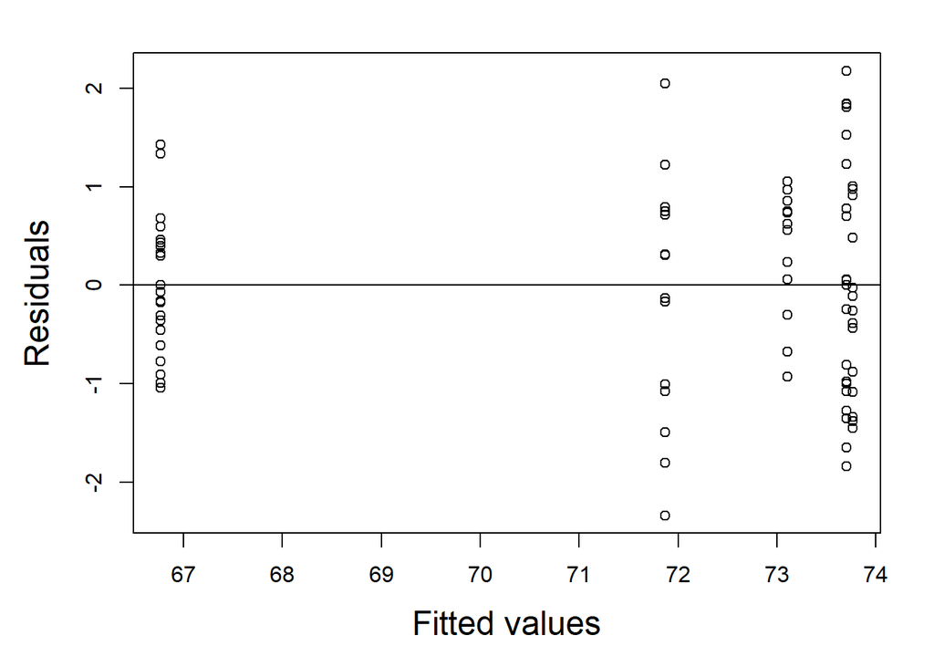

```r
# Homogeneity
E2 <- rstandard(P2_Li)
F2 <- fitted(P2_Li)

#Plot residuals vs fitted values
par(mfrow = c(1,1), mar = c(5,5,2,2), cex.lab = 1.5)
plot(x = F2,
     y = E2,
     xlab = "Fitted values",
     ylab = "Residuals")
abline(h = 0, v = 0)
```

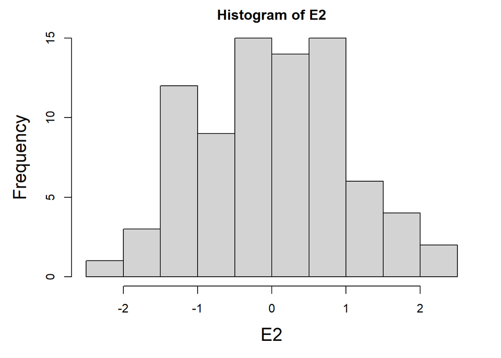

```r
# Normality
hist(E2)
```

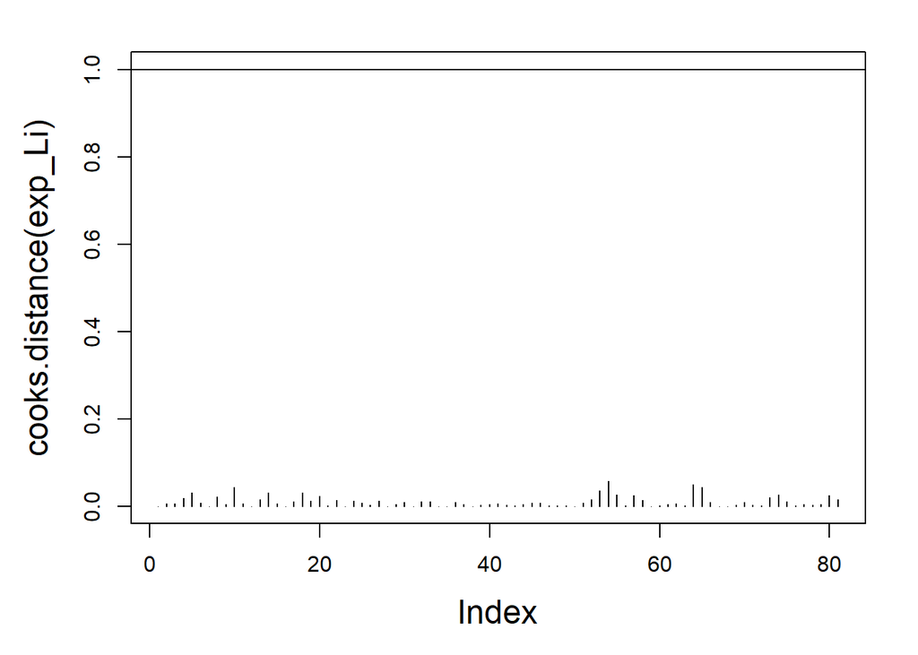

```r
# Influential observations
par(mfrow = c(1,1), mar = c(5,5,2,2), cex.lab = 1.5)
plot(cooks.distance(exp_Li), type = "h", ylim = c(0, 1))
abline(h = 1)
```

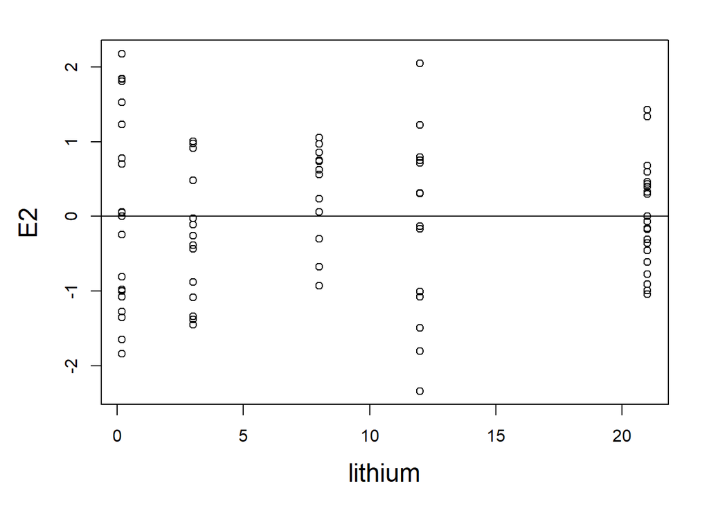

```r
# Independence due to model misfit
lithium_only$E2 <- E2   #Put E2 inside the dataset
plot(E2~lithium, data=lithium_only)
abline(h = 0)
```

*Homogeneity of Residuals:* The residual plot looks acceptable. *Normality of Residuals:* Looks good. *Influential Observations:* No data points exceed the Cook’s distance threshold. *Independence of Residuals:* The residuals show no clear patterns.

*Cross-validation*

```r
MyData <- expand.grid(lithium = seq(min(lithium_only$lithium),
                                  max(lithium_only$lithium+5),
                                  length = 25),
                rate = seq(min(lithium_only$rate),
                                  max(lithium_only$rate),
                                  length = 25))

P2 <- predict(P2_Li, newdata = MyData, se = TRUE)

# 3. Calculate a measure of uncertainty for these predicted values.
#    Say a 95% confidence interval.
MyData$Pred <- P2$fit                    #Predicted values
MyData$selo <- P2$fit - 1.96 * P2$se.fit #lower bound
MyData$seup <- P2$fit + 1.96 * P2$se.fit #lower bound
head(MyData)
```

```
##    lithium     rate     Pred     selo     seup
## 1 0.190000 61.95425 73.70253 72.00666 75.39840
## 2 1.265417 61.95425 73.76300 72.34808 75.17792
## 3 2.340833 61.95425 73.77783 72.53140 75.02427
## 4 3.416250 61.95425 73.74704 72.55550 74.93858
## 5 4.491667 61.95425 73.67062 72.44471 74.89653
## 6 5.567083 61.95425 73.54856 72.23767 74.85946
```

*Visualization:*

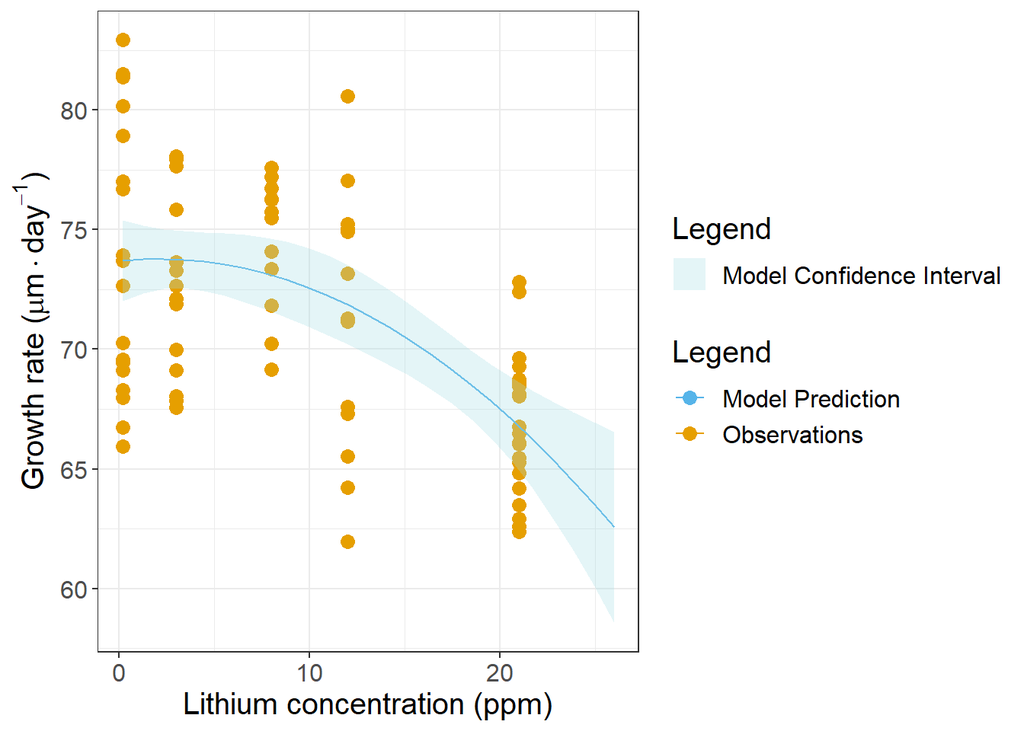

```r
p <- ggplot() +
  geom_point(data = lithium_only,
             aes(y = rate, x = lithium, color = "Observations"),
             shape = 16,
             size = 3) +
  geom_line(data = MyData,
            aes(x = lithium, y = Pred, color = "Model Prediction"),
            linetype = "solid") +
  geom_ribbon(data = MyData,
              aes(x = lithium, ymax = seup, ymin = selo, fill = "Model Confidence Interval"),
              alpha = 0.3) +
  xlab("Lithium concentration (ppm)") +
  ylab(expression(paste("Growth rate ("*mu*"m"%.%"day"^-1*")"))) +
  theme_bw() +
  theme(text = element_text(size = 15)) +
  scale_color_manual(name = "Legend",
                     values = c("Observations" = "#E69F00", "Model Prediction" = "#56B4E9")) +  # Colorblind-friendly palette
  scale_fill_manual(name = "Legend",
                    values = c("Model Confidence Interval" = "#A6DCE5"))  # Colorblind-friendly palette

p
```

### **Check whether the sum of effects from each single stressor follows the additive model**

First, divide the full dataset of growth rates under single stressors into two subsets: 1/3 for validation and 2/3 for model training.

```r
add_split_factor <- function(data, fraction_model = 2/3) {
  data %>%
    group_split(Treatment) %>%
    map_dfr(~ {
      n_rows <- nrow(.x)
      # Calculate number of rows for 'model' and 'validation'
      n_model <- floor(fraction_model * n_rows)
      n_validation <- n_rows - n_model
      # Shuffle indices
      shuffled_indices <- sample(seq_len(n_rows))
      # Assign 'model' and 'validation' labels
      .x$split_factor <- 'validation'  # Default all rows as 'validation'
      .x$split_factor[shuffled_indices[1:n_model]] <- 'model'  # First n_model rows as 'model'
      return(.x)
    })
}

# Add the split_factor column
full_data_single1 <- add_split_factor(full_data_single, fraction_model = 2/3)

table_t<-subset(full_data_single1, split_factor=="model")
table_v<-subset(full_data_single1, split_factor=="validation")
```

Perform the addition of previously selected functions and compare the results with a GAM model to assess whether the additional flexibility in curve fitting improves the overall model performance.

```r
M_add<- lm(GR~poly(T_measured,3)+poly(pH_measured,3)+poly(Li_measured,2), data = table_t)
summary(M_add)
```

```
##
## Call:
## lm(formula = GR ~ poly(T_measured, 3) + poly(pH_measured, 3) +
##     poly(Li_measured, 2), data = table_t)
##
## Residuals:
##      Min       1Q   Median       3Q      Max
## -15.7614  -2.8763  -0.0291   3.1215  10.6607
##
## Coefficients:
##                        Estimate Std. Error t value Pr(>|t|)
## (Intercept)            69.56507    0.40365 172.340  < 2e-16 ***
## poly(T_measured, 3)1   25.40138    4.46353   5.691 1.01e-07 ***
## poly(T_measured, 3)2  -75.58294    4.96793 -15.214  < 2e-16 ***
## poly(T_measured, 3)3   22.24562    4.47392   4.972 2.38e-06 ***
## poly(pH_measured, 3)1  34.90471    4.99846   6.983 2.11e-10 ***
## poly(pH_measured, 3)2 -16.78562    4.54121  -3.696 0.000339 ***
## poly(pH_measured, 3)3  -0.02893    4.47606  -0.006 0.994854
## poly(Li_measured, 2)1 -27.71848    5.00237  -5.541 1.99e-07 ***
## poly(Li_measured, 2)2  -4.63076    4.64836  -0.996 0.321274
## ---
## Signif. codes:  0 '***' 0.001 '**' 0.01 '*' 0.05 '.' 0.1 ' ' 1
##
## Residual standard error: 4.458 on 113 degrees of freedom
## Multiple R-squared:  0.7519, Adjusted R-squared:  0.7343
## F-statistic: 42.81 on 8 and 113 DF,  p-value: < 2.2e-16
```

```r
M_add_gam<- gam(GR~s(T_measured,k=3)+s(pH_measured,k=3)+s(Li_measured,k=2), family = Gamma(link = "log"),data = table_t)
summary(M_add_gam)
```

```
##
## Family: Gamma
## Link function: log
##
## Formula:
## GR ~ s(T_measured, k = 3) + s(pH_measured, k = 3) + s(Li_measured,
##     k = 2)
##
## Parametric coefficients:
##             Estimate Std. Error t value Pr(>|t|)
## (Intercept) 4.236151   0.007026   602.9   <2e-16 ***
## ---
## Signif. codes:  0 '***' 0.001 '**' 0.01 '*' 0.05 '.' 0.1 ' ' 1
##
## Approximate significance of smooth terms:
##                  edf Ref.df      F  p-value
## s(T_measured)  1.993  2.000 123.09  < 2e-16 ***
## s(pH_measured) 1.889  1.988  22.83  < 2e-16 ***
## s(Li_measured) 1.000  1.000  22.17 7.18e-06 ***
## ---
## Signif. codes:  0 '***' 0.001 '**' 0.01 '*' 0.05 '.' 0.1 ' ' 1
##
## R-sq.(adj) =  0.641   Deviance explained = 68.4%
## GCV = 0.0062459  Scale est. = 0.0060233  n = 122
```

*Validate the model*

```r
# Homogeneity
E2 <- rstandard(M_add)
F2 <- fitted(M_add)
```

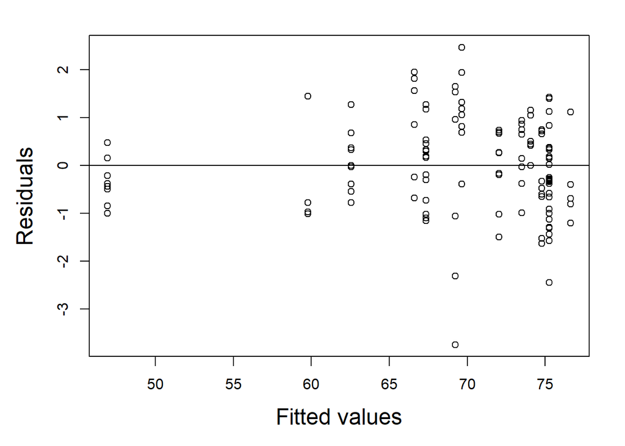

```r
#Plot residuals vs fitted values
par(mfrow = c(1,1), mar = c(5,5,2,2), cex.lab = 1.5)
plot(x = F2,
     y = E2,
     xlab = "Fitted values",
     ylab = "Residuals")
abline(h = 0, v = 0)
```

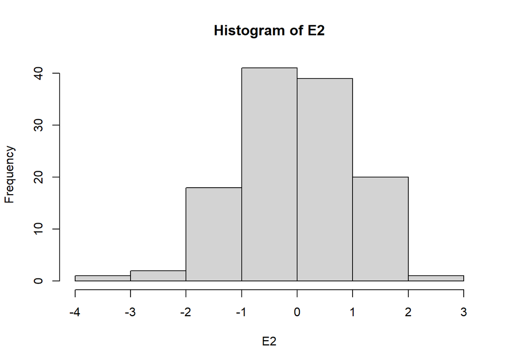

```r
# Normality
hist(E2)
```

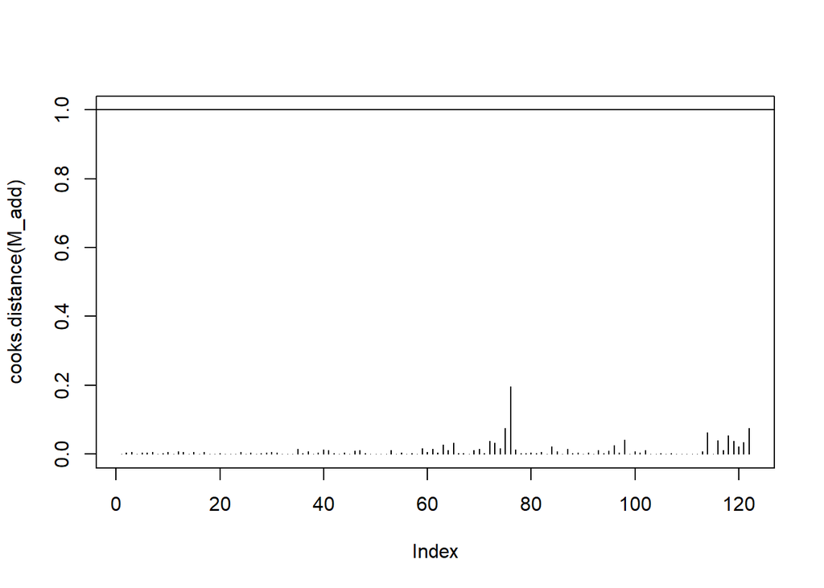

```r
# Influential observations
plot(cooks.distance(M_add), type = "h", ylim = c(0, 1))
abline(h = 1)
```

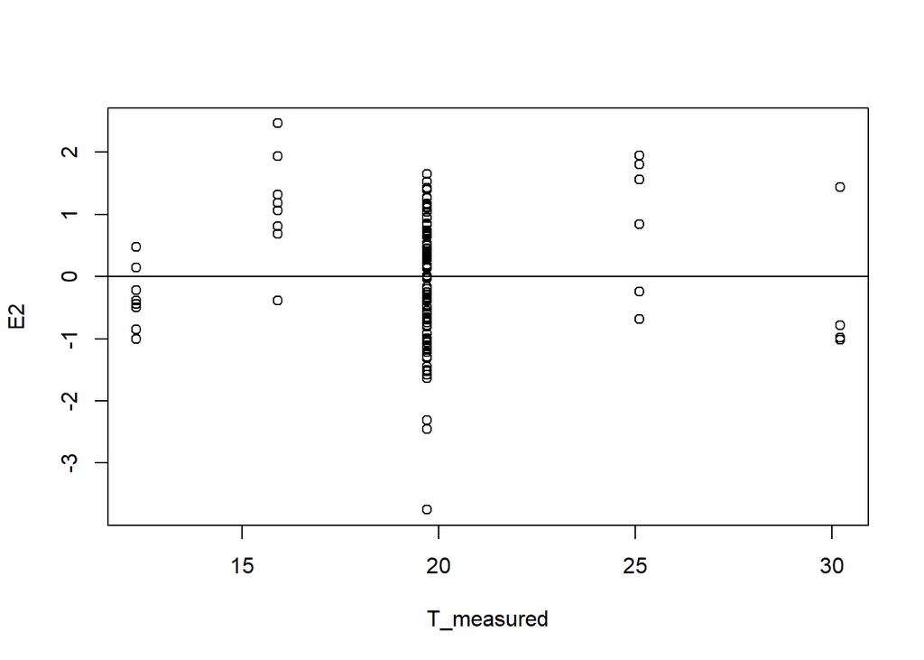

```r
# Independence due to model misfit
table_t$E2 <- E2   #Put E2 inside the dataset
plot(E2~T_measured, data=table_t)
abline(h = 0)
```

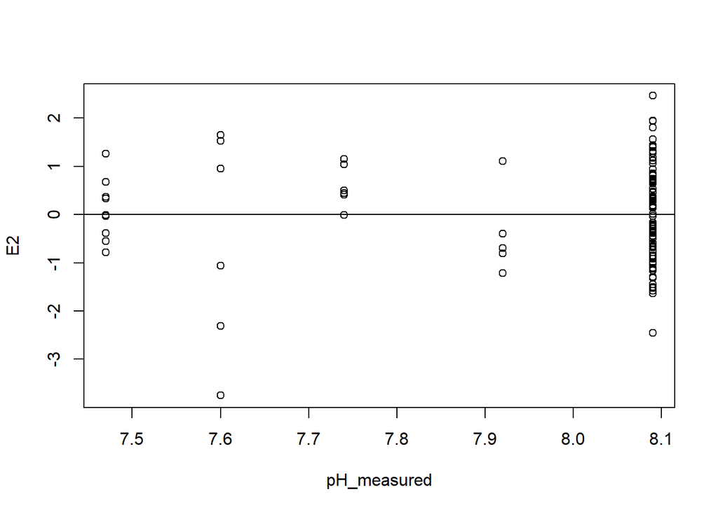

```r
plot(E2~pH_measured, data=table_t)
abline(h = 0)
```

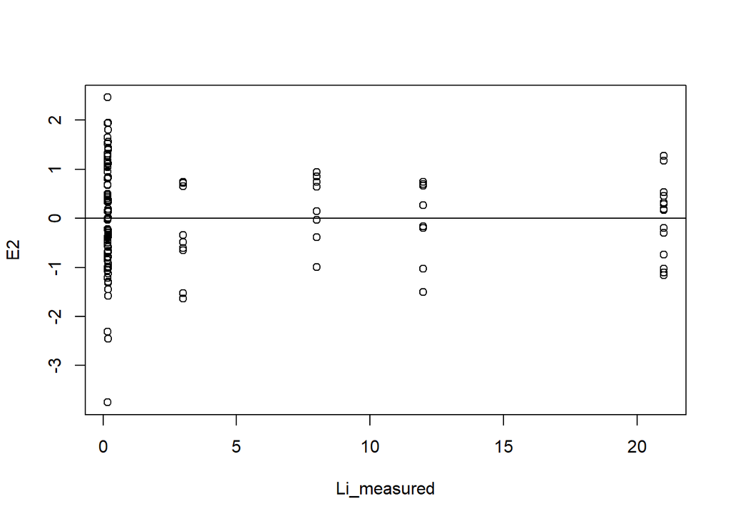

```r
plot(E2~Li_measured, data=table_t)
abline(h = 0)
```

*Homogeneity of Residuals:* The residual are symmetrically spread.

*Normality of Residuals:* Actually, residuals appear normally distributed.

*Influential Observations:* No data points exceed the Cook’s distance threshold.

*Independence of Residuals:* No clear patterns are observed in residuals when plotted against predictors.

*Cross-validation with the remaining of data*

Calculate predictions for the validation dataset and derive a 95% confidence interval for these predicted values.

```r
P2 <- predict(M_add, newdata = table_v, se = TRUE)

# 3. Calculate a measure of uncertainty for these predicted values.
#    Say a 95% confidence interval.
table_v$Pred <- P2$fit                    #Predicted values
table_v$selo <- P2$fit - 1.96 * P2$se.fit #lower bound
table_v$seup <- P2$fit + 1.96 * P2$se.fit #lower bound
head(table_v)
```

```
## # A tibble: 6 × 13
##   Treatment T_targeted pH_targeted Li_targeted T_measured pH_measured
##   <chr>          <dbl>       <dbl>       <dbl>      <dbl>       <dbl>
## 1 L1                20         8.1        0.18       19.7        8.09
## 2 L1                20         8.1        0.18       19.7        8.09
## 3 L1                20         8.1        0.18       19.7        8.09
## 4 L1                20         8.1        0.18       19.7        8.09
## 5 L1                20         8.1        0.18       19.7        8.09
## 6 L1                20         8.1        0.18       19.7        8.09
## # ℹ 7 more variables: Li_measured <dbl>, BL <dbl>, GR <dbl>,
## #   split_factor <chr>, Pred <dbl>, selo <dbl>, seup <dbl>
```

Prepare the validation data set by organizing treatment identifiers and grouping factors for better visualization.

```r
table_v<-table_v%>%arrange(Treatment)

substrRight <- function(x, n){
  substr(x, nchar(x)-n+1, nchar(x))
}
table_v$Treatment_ID_gr<-substrRight(table_v$Treatment, 1)
substrLeft <- function(x, n){
  substr(x, 1, 1)
}
table_v$Treatment_ID<-substrLeft(table_v$Treatment)
table_v$Treatment_ID<-as.factor(table_v$Treatment_ID)
table_v$Treatment_ID_gr<-as.factor(table_v$Treatment_ID_gr)

trend2<-data.frame(Pred=seq(from = min(table_v$Pred)-10,
                      to = max(table_v$Pred)+10,
                      length = 100))
trend2$GR<-trend2$Pred

out2<-summary(M_add)
```

*Visualization:*

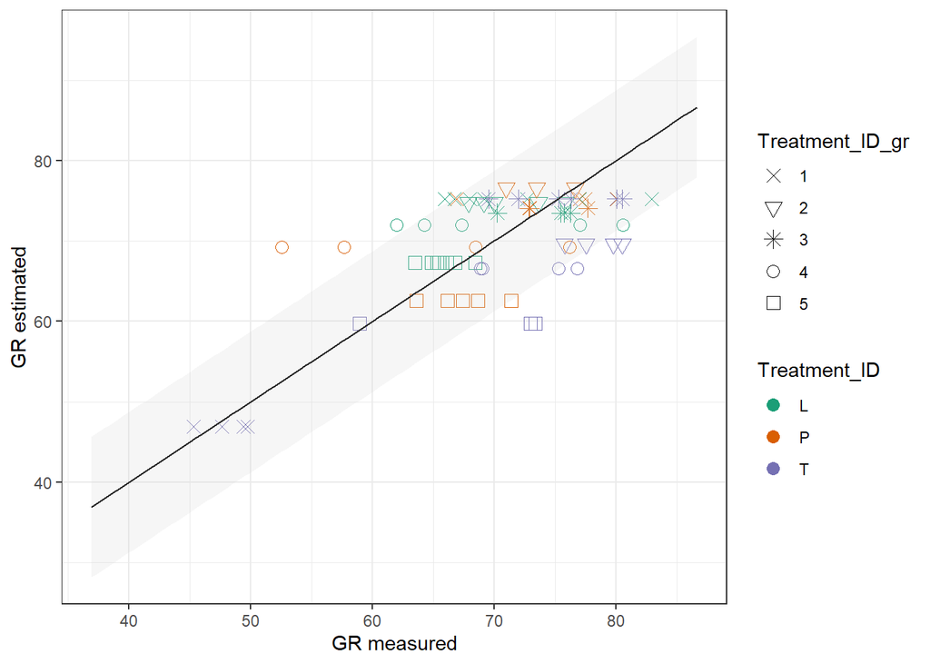

```r
ggplot() +
  geom_point(data = table_v,
             aes(y = Pred, x = GR, shape = Treatment_ID_gr, color = Treatment_ID),
             size = 3) +
  scale_shape_manual(values = c(4, 6, 8, 1, 0)) +
  scale_color_manual(values = c("#1B9E77", "#D95F02", "#7570B3", "#E7298A", "#66A61E")) +
  xlab("GR measured") +
  ylab("GR estimated") +
  theme(text = element_text(size = 15)) +
  geom_line(data = trend2,
            aes(x = GR, y = Pred), color = "black") +
  geom_ribbon(data = trend2,
              aes(x = GR, ymax = Pred + (1.96 * out2$sigma),
                  ymin = Pred - (1.96 * out2$sigma)),
              alpha = 0.2, fill = "lightgrey") +
  theme_bw()
```

Observed data points are plotted against the predicted growth rates using the additive model. A ribbon is included to represent the confidence interval around predictions. The cross-validation shows that the model performs reasonably well for data from single-stressor experiments.

### **Addition of data from multiple stressor experiment**

Load the data set containing growth rate data under multiple stressor conditions.

```r
full_multiple <- read_excel("~/Personal documents/OA/GR_experiment/correspondance with einar/full_multiple.xlsx")
```

Use the previously developed additive model to predict growth rates for the multiple stressor dataset. Additionally, calculate a 95% confidence interval for the predicted values.

```r
P_multi <- predict(M_add, newdata = full_multiple, se = TRUE)

# 3. Calculate a measure of uncertainty for these predicted values.
#    Say a 95% confidence interval.
full_multiple$Pred <- P_multi$fit                    #Predicted values
full_multiple$selo <- P_multi$fit - 1.96 * P_multi$se.fit #lower bound
full_multiple$seup <- P_multi$fit + 1.96 * P_multi$se.fit #lower bound
head(full_multiple)
```

```
## # A tibble: 6 × 15
##   Treatment   Treatm    BL    GR T_targed T_measured pH_targed pH_measured
##   <chr>       <chr>  <dbl> <dbl>    <dbl>      <dbl>     <dbl>       <dbl>
## 1 ML1P2_20_R1 A       332.  61.8       20       20.5       7.7        7.55
## 2 ML1P2_20_R1 A       298.  53.1       20       20.5       7.7        7.55
## 3 ML1P2_20_R1 A       345.  65.0       20       20.5       7.7        7.55
## 4 ML1P2_20_R1 A       374.  72.4       20       20.5       7.7        7.55
## 5 ML1P2_20_R1 A       364.  69.7       20       20.5       7.7        7.55
## 6 ML1P2_20_R1 A       384.  74.7       20       20.5       7.7        7.55
## # ℹ 7 more variables: Li_targed <dbl>, Li_measured <dbl>, Treatment_T_gr <chr>,
## #   `Treatment_pH&Li_gr` <chr>, Pred <dbl>, selo <dbl>, seup <dbl>
```

*Verify alignment between predicted and measured growth rates*

Organize the dataset by treatment and prepare it for visualization. Create a trend line for comparison and set up grouping variables for treatment combinations.

```r
full_multiple<-full_multiple%>%arrange(Treatment)

trend3<-data.frame(Pred=seq(from = min(full_multiple$Pred)-10,
                      to = max(full_multiple$Pred)+10,
                      length = 100))
trend3$GR<-trend3$Pred

out2<-summary(M_add)

full_multiple$Treatment_T_gr<-as.factor(full_multiple$Treatment_T_gr)
full_multiple$`Treatment_pH&Li_gr`<-as.factor(full_multiple$`Treatment_pH&Li_gr`)
```

*Visualize model performance for multiple stressors*

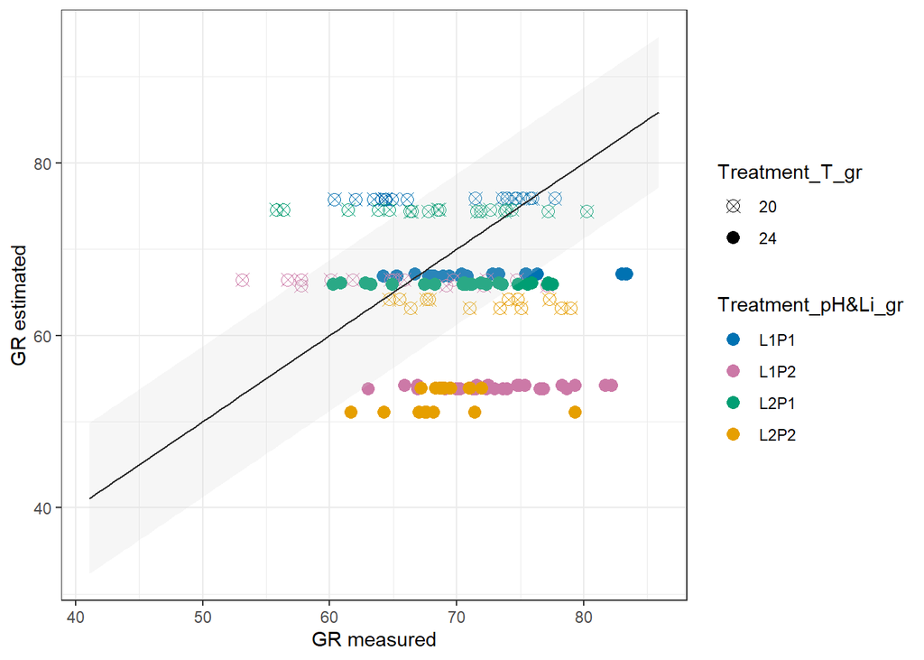

```r
ggplot() +
  geom_point(data = full_multiple,
             aes(y = Pred, x = GR, shape = Treatment_T_gr, color = `Treatment_pH&Li_gr`),
             size = 3) +
  scale_shape_manual(values = c(13, 16)) +
  scale_color_manual(values = c("#0072B2", "#CC79A7", "#009E73", "#E69F00")) +
  xlab("GR measured") +
  ylab("GR estimated") +
  theme(text = element_text(size = 15)) +
  geom_line(data = trend3,
            aes(x = GR, y = Pred), color = "black") +
  geom_ribbon(data = trend3,
              aes(x = GR, ymax = Pred + (1.96 * out2$sigma),
                  ymin = Pred - (1.96 * out2$sigma)),
              alpha = 0.2, fill = "lightgrey") +
  theme_bw()
```

For treatments 24L1P2 and 24L2P2, the measured growth rates exceeded the predicted values, indicating that the additive model does not adequately capture interactions between stressors.

Unfortunately, the current dataset from the multiple stressor experiments is insufficient to model synergistic interactions, as the data points do not fully cover the performance curve under combined stressor conditions.

### Comparing growth rates under single and multiple stressor experiments

The objective is to assess whether growth rates measured during single stressor experiments differ statistically from those measured during multiple stressor experiments under comparable conditions.

**Li case exploration**

Prepare the data set by combining lithium-specific data from single and multiple stressor experiments. Add a column to indicate whether the data comes from single or multiple stressor conditions.

```r
Li_case<-lithium_only[,1:4]
MS_Li_only<-full_multiple[,c(1,9, 10,4)]
names(Li_case)<-c("Treatment" ,"Li_targeted", "Li_measured","GR")
names(MS_Li_only)<-c("Treatment" ,"Li_targeted", "Li_measured","GR")
MS_Li_only$Stressors<-rep("Multiple",nrow(MS_Li_only))
Li_case$Stressors<-rep("Single",nrow(Li_case))
Li_case_full<-rbind(Li_case,MS_Li_only)
```

*Visualization of growth rates by lithium concentration*

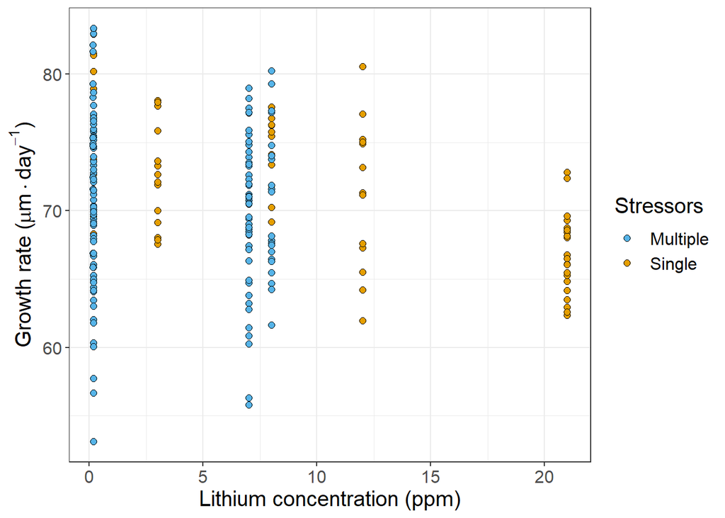

```r
p <- ggplot() +
  geom_point(data = Li_case_full,
             aes(y = GR, x = Li_measured, fill = Stressors),
             shape = 21,
             size = 2) +
  xlab("Lithium concentration (ppm)") +
  ylab(expression(paste("Growth rate ("*mu*"m"%.%"day"^-1*")"))) +
  theme_bw() +
  theme(text = element_text(size = 15)) +
  scale_fill_manual(name = "Stressors",
                    values = c("Single" = "#E69F00", "Multiple" = "#56B4E9"))

p
```

*Statistical tests for lithium-experiment data*

Subset the dataset to include only the relevant lithium target concentrations (0.18 ppm and 7 ppm). Ensure the data is formatted correctly for statistical testing.

```r
Li_case_for_stat<-subset(Li_case_full, Li_targeted==0.18|Li_targeted==7)
Li_case_for_stat$Treatment<-as.factor(Li_case_for_stat$Treatment)
# Ensure GR is numeric
Li_case_for_stat$GR <- as.numeric(Li_case_for_stat$GR)

# Subset data by Li_targeted levels
Li_case_for_stat_018<- subset(Li_case_for_stat, Li_targeted == 0.18)
Li_case_for_stat_7 <- subset(Li_case_for_stat, Li_targeted == 7)

# Shapiro-Wilk Test
shapiro_results <- Li_case_for_stat %>%
  group_by(Treatment) %>%
  summarise(shapiro_p_value = shapiro.test(GR)$p.value)

cat("\nShapiro-Wilk Test Results:\n")
```

```
##
## Shapiro-Wilk Test Results:
```

```r
print(as.data.frame(shapiro_results))  # Convert tibble to data frame
```

```
##      Treatment shapiro_p_value
## 1           L1       0.1165839
## 2           L3       0.1247844
## 3  ML1P1_20_R1       0.2574815
## 4  ML1P1_20_R2       0.7926540
## 5  ML1P1_24_R1       0.3203047
## 6  ML1P1_24_R2       0.4595453
## 7  ML1P2_20_R1       0.9498778
## 8  ML1P2_20_R2       0.6631284
## 9  ML1P2_24_R1       0.6909674
## 10 ML1P2_24_R2       0.9254671
## 11 ML2P1_20_R1       0.3933359
## 12 ML2P1_20_R2       0.4900002
## 13 ML2P1_24_R1       0.6498643
## 14 ML2P1_24_R2       0.3040053
## 15 ML2P2_20_R1       0.7456292
## 16 ML2P2_20_R2       0.2634574
## 17 ML2P2_24_R1       0.7517508
## 18 ML2P2_24_R2       0.2377252
```

```r
# Levene's Test
levene_test_018 <- leveneTest(GR ~ Stressors, data = Li_case_for_stat_018)
levene_test_7 <- leveneTest(GR ~ Stressors, data = Li_case_for_stat_7)

levene_results_table <- data.frame(
  Group = c("Li targeted = 0.18 ppm", "Li targeted = 7 ppm"),
  F_value = c(levene_test_018$`F value`[1], levene_test_7$`F value`[1]),
  P_value = c(levene_test_018$`Pr(>F)`[1], levene_test_7$`Pr(>F)`[1])
)


cat("\nLevene's Test Results:\n")
```

```
##
## Levene's Test Results:
```

```r
print(levene_results_table)
```

```
##                    Group   F_value    P_value
## 1 Li targeted = 0.18 ppm 0.1936581 0.66084852
## 2    Li targeted = 7 ppm 4.3342827 0.04047043
```

```r
# Wilcoxon rank-sum tests
Li_case_for_stat_018_s<-subset(Li_case_for_stat_018, Stressors=="Single")
Li_case_for_stat_018_m<-subset(Li_case_for_stat_018, Stressors=="Multiple")

Li_case_for_stat_7_s<-subset(Li_case_for_stat_7, Stressors=="Single")
Li_case_for_stat_7_m<-subset(Li_case_for_stat_7, Stressors=="Multiple")

wilk_018<-wilcox.test(Li_case_for_stat_018_s$GR,Li_case_for_stat_018_m$GR)
wilk_7<-wilcox.test(Li_case_for_stat_7_s$GR,Li_case_for_stat_7_m$GR)


wilk_results_table <- data.frame(
  Group = c("Li targeted = 0.18 ppm", "Li targeted = 7 ppm"),
  W_value = c(wilk_018$statistic, wilk_7$statistic),
  P_value = c(wilk_018$p.value, wilk_7$p.value)
)

cat("\nWilcoxon Rank-Sum Test Results:\n")
```

```
##
## Wilcoxon Rank-Sum Test Results:
```

```r
print(wilk_results_table)
```

```
##                    Group W_value     P_value
## 1 Li targeted = 0.18 ppm    1047 0.043861335
## 2    Li targeted = 7 ppm     669 0.002501827
```

```r
# ANOVA

anova_18<-aov(GR~Stressors, data=Li_case_for_stat_018)
anova_7<-aov(GR~Stressors, data=Li_case_for_stat_7)
s_anova_18<-summary(anova_18)
s_anova_7<-summary(anova_7)

anova_results_table <- data.frame(
  Group = c("Li targeted = 0.18 ppm", "Li targeted = 7 ppm"),
  F_value = c(summary(anova_18)[[1]]$`F value`[1], summary(anova_7)[[1]]$`F value`[1]),
  P_value = c(summary(anova_18)[[1]]$`Pr(>F)`[1], summary(anova_7)[[1]]$`Pr(>F)`[1])
)

cat("\nANOVA Results:\n")
```

```
##
## ANOVA Results:
```

```r
print(anova_results_table)
```

```
##                    Group  F_value     P_value
## 1 Li targeted = 0.18 ppm 5.279575 0.023681472
## 2    Li targeted = 7 ppm 8.702142 0.004141273
```

*Visualization of statistical results*

Create a boxplot to compare growth rates between single and multiple stressor conditions, grouped by lithium target concentrations (0.18 ppm and 7 ppm). Use facets to separate the groups for clearer interpretation.

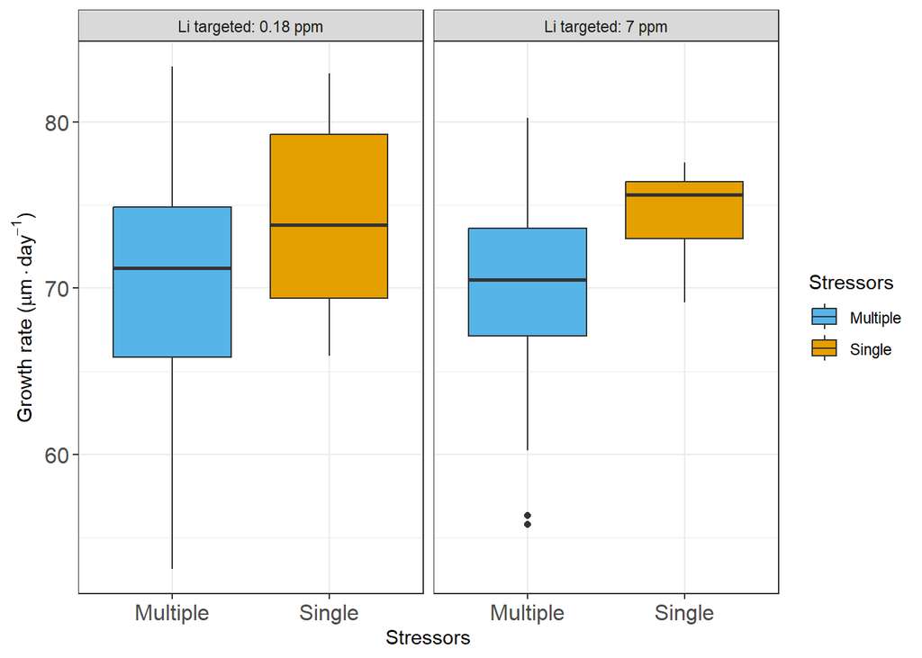

```r
Li_case_for_stat$Li_targeted_label <- factor(
  Li_case_for_stat$Li_targeted,
  levels = c(0.18, 7.00),
  labels = c("Li targeted: 0.18 ppm", "Li targeted: 7 ppm")
)

p1 <- ggplot(Li_case_for_stat, aes(x = Stressors, y = GR, fill = Stressors)) +
  geom_boxplot() +
  facet_grid(~Li_targeted_label) +
  labs(
    x = "Stressors",
    y = expression(paste("Growth rate ("*mu*"m"%.%"day"^-1*")"))
  ) +
  theme_bw() +
  theme(axis.text = element_text(size = 12)) +
  scale_fill_manual(name = "Stressors",
                    values = c("Single" = "#E69F00", "Multiple" = "#56B4E9"))

p1
```

*Shapiro-Wilk Test:* Results indicate that growth rate data is normally distributed in allgroups.

*Levene’s Test:* Confirms homogeneity of variances between multiple and single stressor conditions for concentration of 0.18 ppm and rejects for concentration 7 ppm.

*Wilcoxon Rank-Sum Test:* Highlights differences in median growth rates between multiple and single stressor experiments for both concentrations.

*ANOVA:* We can ignore results since samples have different size and homogeneity.

**Temperature case exploration**

Prepare the data set by combining temperature-specific data from single and multiple stressor experiments. Add a column to indicate whether the data comes from single or multiple stressor conditions.

```r
temp_case<-temp_only[,1:4]
MS_temp_only<-full_multiple[,c(1,5,6,4)]
names(temp_case)<-c("Treatment" ,"T_targeted", "T_measured","GR")
names(MS_temp_only)<-c("Treatment" ,"T_targeted", "T_measured","GR")
MS_temp_only$Stressors<-rep("Multiple",nrow(MS_temp_only))
temp_case$Stressors<-rep("Single",nrow(temp_case))
temp_case_full<-rbind(temp_case,MS_temp_only)
```

*Visualization of growth rates by temperature*

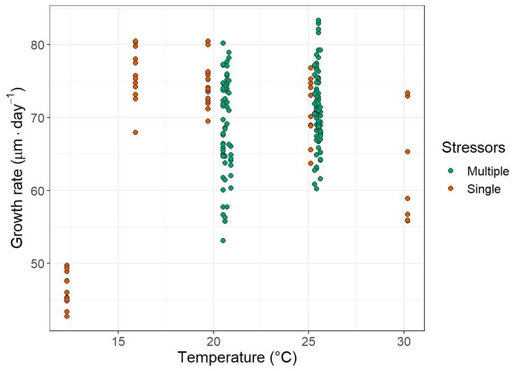

```r
p <- ggplot() +
  geom_point(data = temp_case_full,
             aes(y = GR, x = T_measured, fill = Stressors),
             shape = 21,
             size = 2) +
  xlab("Temperature (°C)") +
  ylab(expression(paste("Growth rate ("*mu*"m"%.%"day"^-1*")"))) +
  theme_bw() +
  theme(text = element_text(size = 15)) +
  scale_fill_manual(name = "Stressors",
                    values = c("Single" = "#D55E00", "Multiple" = "#009E73"))

p
```

*Statistical tests for temperature-dependent data*